# Visualisasi Data dengan `ggplot2`

Institut Teknologi Statistika dan Bisnis Muhammadiyah Semarang

**Deden Istiawan**

- deden.istiawan@itesa.ac.id
- [@dedenistiawan](https://twitter.com/dedenistiawan)

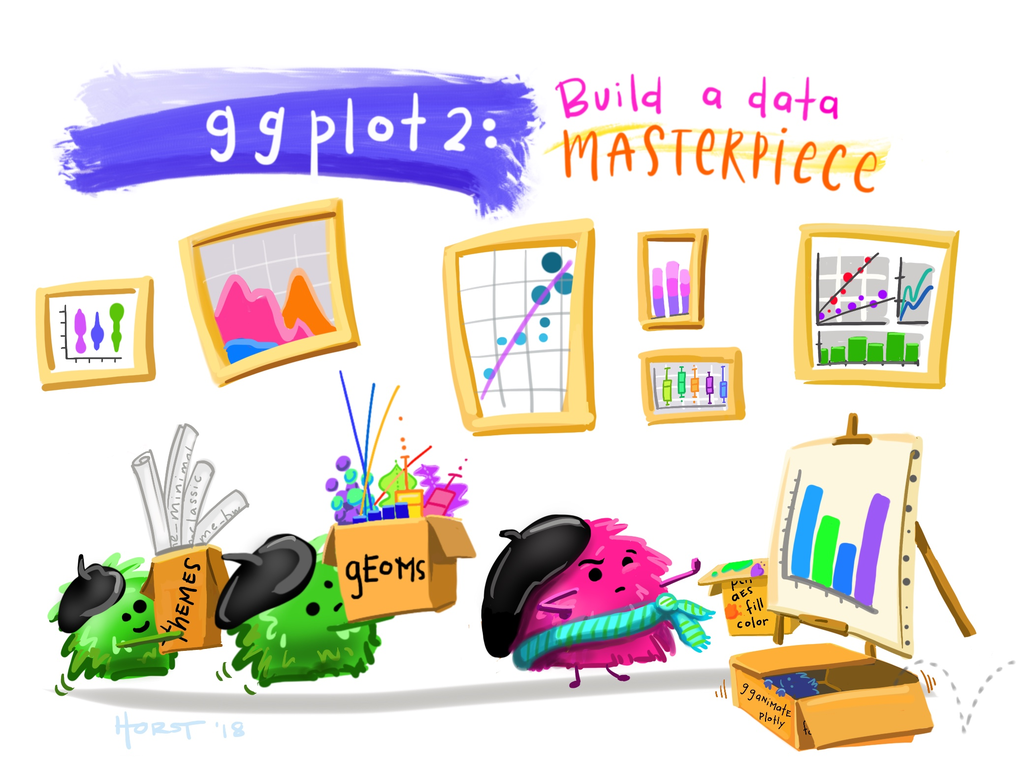

Illustration ggplot2

# 1 Pengantar

Selamat datang di mata kuliah Visualisasi Data dengan `ggplot2`!

Dalam mata kuliah ini, kita akan membahas konsep dan keterampilan untuk membuat visualisasi data yang efektif menggunakan `ggplot2` di R. Kita akan memulai dengan mereview dasar-dasar ggplot, kemudian memperdalam kemampuan dengan membuat grafik (termasuk penyesuaian skala, tema, pelabelan langsung, dsb) sambil memperkuat prinsip-prinsip visualisasi data dengan mempertimbangkan dengan cermat alasan kita mengubah (atau tidak mengubah) setiap komponen grafik. Selanjutnya, kita akan belajar membuat beberapa jenis grafik modern dan menarik yang jarang digunakan, sebelum menggabungkannya menjadi gambar gabungan menggunakan paket `patchwork`. Sebagai penutup, kita akan membangun sebuah peta dengan menggunakan ggplot, untuk memperkuat pemahaman bahwa alat dan konsep yang dipelajari dapat diterapkan pada berbagai jenis data dan visualisasi.

Mahasiswa harus dapat:

- Menginstal dan memasang paket R
- Membuat grafik `ggplot2` dasar dalam R
- Bekerja dengan nyaman dalam skrip R atau R Markdown

## 1.1 Outline Dataviz

Berikut adalah beberapa hal yang akan dipelajari pada mata kuliah visualisasi data dengan `ggplot2` di R:

Mata kuliah ini dirancang untuk memberikan pemahaman mendalam tentang hierarki konseptual dalam visualisasi data serta keterampilan praktis dalam menggunakan `ggplot2` di R. Topik-topik yang akan dibahas meliputi:

1. Dasar-dasar `ggplot2`
   - Pemetaan estetika (aesthetic mapping)
   - Tema dan penyesuaiannya
   - Penambahan label
   - Fitur facet (termasuk perbandingan antara facet grid dan facet wrap)
   - Mengatur urutan elemen data (misalnya, dengan `fct_reorder`)
2. Kustomisasi Lanjutan di `ggplot2`
   - Menggunakan `scales` untuk menentukan jeda dan label yang bermakna
   - Skema warna yang menarik (dengan tambahan dukungan dari `paletteer`)
   - Detail tema: garis kisi, warna panel, margin, dan lainnya
   - Anotasi langsung sebagai alternatif legenda
   - Label yang tidak saling bertumpuk dengan `ggrepel`
   - Penyorotan elemen data untuk meningkatkan kejelasan menggunakan `gghighlight`
3. Membuat gambar Komposit dengan `patchwork`  
   Memanfaatkan paket `patchwork` untuk menggabungkan berbagai grafik menjadi satu tata letak yang menarik.
4. Jenis Grafik Baru yang Layak Dicoba
   - Plot marginal untuk menunjukkan distribusi tambahan
   - Beeswarm plots dengan `ggbeeswarm`
   - Heatmap dengan `geom_tile()`
   - Membuat peta yang menarik menggunakan `ggplot2`
5. Ekspor dan Penyimpanan Grafik Teknik dan praktik terbaik untuk menyimpan hasil visualisasi Anda dengan kualitas tinggi.

Mata kuliah ini akan membantu mahasiswa memahami prinsip-prinsip visualisasi data yang baik sekaligus menguasai alat-alat yang diperlukan untuk membuat grafik yang elegan dan bermakna.

# 2 Referensi dan data

## 2.1 R packages

Terima kasih yang sebesar-besarnya kepada para pengembang, kontributor, pengajar, dan seluruh komunitas R atas kontribusi luar biasa dalam membangun alat, menciptakan sumber daya, dan menciptakan lingkungan yang mendukung untuk belajar. Upaya kolektif Anda memungkinkan kami untuk terus mengeksplorasi dan berkembang dalam bidang visualisasi data.

Ucapan terima kasih khusus ditujukan kepada para pengembang dan pemelihara paket R berikut yang sangat penting dalam perjalanan pembelajaran ini:

- `tidyverse`: Wickham et al., (2019). Welcome to the tidyverse. Journal of Open Source Software, 4(43), 1686, https://doi.org/10.21105/joss.01686
- `ggplot2`: H. Wickham. ggplot2: Elegant Graphics for Data Analysis. Springer-Verlag New York, 2016.
- `ggrepel`: Kamil Slowikowski (2021). ggrepel: Automatically Position Non-Overlapping Text Labels with ‘ggplot2’. R package version 0.9.1. https://github.com/slowkow/ggrepel
- `gghighlight`: Hiroaki Yutani (2020). gghighlight: Highlight Lines and Points in ‘ggplot2’. R package version 0.3.1. https://github.com/yutannihilation/gghighlight/
- `R Markdown`: Yihui Xie and J.J. Allaire and Garrett Grolemund (2018). R Markdown: The Definitive Guide. Chapman and Hall/CRC. ISBN 9781138359338. URL https://bookdown.org/yihui/rmarkdown.
- `sf`: Pebesma, E., 2018. Simple Features for R: Standardized Support for Spatial Vector Data. The R Journal 10 (1), 439-446, https://doi.org/10.32614/RJ-2018-009
- `paletteer`: See AUTHORS file. (2021). paletteer: Comprehensive Collection of Color Palettes. R package version 1.3.0. https://github.com/EmilHvitfeldt/paletteer
- `gapminder`: Jennifer Bryan (2017). gapminder: Data from Gapminder. https://github.com/jennybc/gapminder, http://www.gapminder.org/data/, https://doi.org/10.5281/zenodo.594018.
- `janitor`:Sam Firke (2021). janitor: Simple Tools for Examining and Cleaning Dirty Data. R package version 2.1.0. https://github.com/sfirke/janitor

## 2.2 Data Praktikum

Data yang digunakan dari [Jornada Basin Long Term Ecological Research site](https://lter.jornada.nmsu.edu/) di New Mexico, bagian dari jaringan US Long Term Ecological Research (LTER):

- Lightfoot, D. dan W.G. Whitford. 2020. Data jebakan kadal di 11 lokasi studi NPP di situs Jornada Basin LTER, 1989-2006 versi 37. Environmental Data Initiative. https://doi.org/10.6073/pasta/4a6e258fb49c31e222ecbbcfd128967f

Dari paket data tersebut:  
“Paket data ini mencakup data tentang kadal yang diambil dari jebakan di 11 plot konsumen di situs Jornada Basin LTER dari tahun 1989-2006. Tujuan penelitian ini adalah untuk mengamati bagaimana pergeseran vegetasi akibat proses desertifikasi di Gurun Chihuahuan telah mengubah ketersediaan sumber daya bagi konsumen secara spasial dan temporal. Perubahan desertifikasi di Jornada Basin meliputi peralihan dari padang rumput ke komunitas yang didominasi oleh semak dan perubahan besar pada tanah. Jika sistem padang rumput merespons hujan tanpa penundaan yang signifikan, sementara sistem semak tidak, maka spesies konsumen seharusnya mencerminkan perbedaan ini. Selain itu, pergeseran dari padang rumput ke semak menyebabkan heterogenitas struktural yang lebih besar pada habitat. Kami berhipotesis bahwa populasi, keanekaragaman, dan kepadatan beberapa konsumen akan lebih tinggi di padang rumput dibandingkan di semak belukar, serta berkorelasi dengan NPP (Net Primary Productivity) dari lokasi penelitian. Kadal ditangkap menggunakan jebakan di 11 plot konsumen LTER II/III (subset dari plot NPP) setiap tiga bulan selama 2 minggu setiap kuartal. Variabel yang diukur meliputi spesies, jenis kelamin, status penangkapan ulang, panjang moncong-ventral, panjang total, berat badan, dan kondisi ekor (patah atau utuh). Penelitian ini telah selesai.”

Terdapat total 16 variabel dalam data `lizards.csv` yang akan kita baca. Variabel-variabel yang akan digunakan dalam workshop ini adalah:

- **`date`**: tanggal pengumpulan data
- **`scientific_name`**: nama ilmiah kadal
- **`common_name`**: nama umum kadal
- **`site`**: kode lokasi penelitian
- **`sex`**: jenis kelamin kadal (`m` = jantan; `f` = betina; `j` = juvenil)
- **`sv_length`**: panjang moncong ke ventral (dalam milimeter)
- **`total_length`**: panjang tubuh (dalam milimeter)
- **`toe_num`**: nomor penanda pada jari kaki
- **`weight`**: berat tubuh (dalam gram)
- **`tail`**: kondisi ekor (`b` = patah; `w` = utuh)

## 2.3 Data Spasial Vegetasi Jornada

Data ini berasal dari [Jornada Basin LTER Spatial Data](https://lter.jornada.nmsu.edu/spatial-data/): **Vegetasi Dominan di JER dan CDRRC tahun 1998**. Data ini memuat informasi tentang vegetasi dominan dan subdominannya di **Jornada Experimental Range (JER)** dan **Chihuahuan Desert Rangeland Research Center (CDRRC)** pada tahun 1998.

Data ini diterbitkan dalam:  
Gibbens, R. P., McNeely, R. P., Havstad, K. M., Beck, R. F., & Nolen, B. (2005). Vegetation changes in the Jornada Basin from 1858 to 1998. *Journal of Arid Environments, 61*(4), 651-668.

## 2.4 Membuat Dokumen R Markdown Baru atau Skrip R

Saya akan menggunakan **R Markdown** selama perkuliahan, tetapi Anda dapat mengikuti workshop ini baik dengan **file .Rmd** maupun **skrip R (.R)**.

## 2.5 Install R packages

```r
library(tidyverse)
library(here)
library(janitor)

library(patchwork)
library(ggrepel)
library(gghighlight)
library(paletteer)
library(ggExtra)
library(ggbeeswarm)

# Spatial data
library(sf)

library(gapminder)
```

## 2.6 Read lizard data

```r
lizards <- read_csv(here("data_tidy", "lizards.csv"))
```